# Homework 5 (due Thursday, November 8th)

I agree to abide by the Stern Code of Conduct - (NAME & NYU ID)

## Question 1: Bechdel test hypothesis tests

In this problem you will repeat experiments studying the `bechdel` data by analyzing films from different ranges of years.

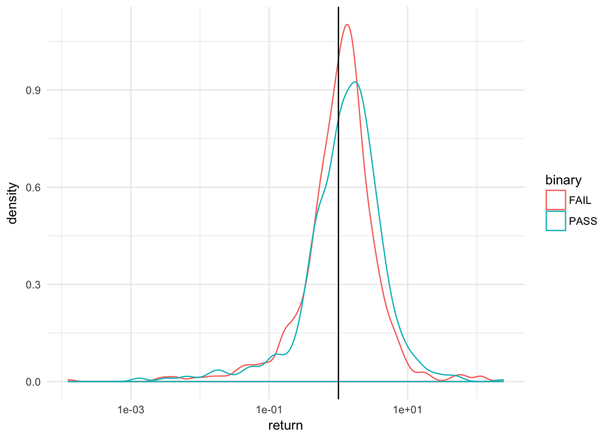

```r
# Remove movies that have NA values for some variables
# and create the return = gross/budget variable
# (adjusted to 2013 dollars for inflation)
movies <- bechdel %>% na.omit %>%
  filter(year > 1993) %>%
  mutate(return = domgross_2013/budget_2013)
# Density (smooth histogram) of returns, log-scale
# vertical line at the break-even point
qplot(return, geom = "density", color = binary, data = movies) +
  scale_x_log10() + geom_vline(xintercept = 1) + theme_minimal()
```

### Intervals and tests for difference in mean returns

#### Films from 1994-2003

```r
# t-test for difference in means
movies90s <- filter(movies, year <= 2003)
t.test(return ~ binary, conf.int = T, movies90s)
```

```
##
##  Welch Two Sample t-test
##
## data:  return by binary
## t = -0.75852, df = 427.73, p-value = 0.4486
## alternative hypothesis: true difference in means is not equal to 0
## 95 percent confidence interval:
##  -3.050605  1.351697
## sample estimates:
## mean in group FAIL mean in group PASS
##           2.742676           3.592130
```

Does the 95% confidence interval contain 0?

```
Answer here
```

Do we reject the null hypothesis of equal means at the 5% significance level?

```
Answer here
```

#### Films from 2004-2013

```r
movies00s <- filter(movies) # use filter to get movies released after 2003
# copy the t.test above but change movies90s to movies00s
```

Does the 95% confidence interval contain 0?

```
Answer here
```

Do we reject the null hypothesis of equal means at the 5% significance level?

```
Answer here
```

### Intervals and tests for difference in median returns

1. Copy the previous section and paste it here
2. Change “means” to “medians”
3. Change `t.test` to `wilcox.test`
4. Interpret the results and change your answers as necessary
5. Delete this list of instructions

### Why are some of the results different?

Let’s assume that the populations means/medians are the same in 2004-2013 as they are in 1994-2003. We may still make different conclusions based on the confidence intervals or tests depending on which of the two samples we analyze. Why?

```
One or two sentences here
```

The answers for the medians are not the same as the answers for the means, why? (Hint: look at the plot)

```
One or two sentences here
```

## Question 2: types of errors

### Part 1: type 1 errors (false positives)

Throughout Part 1 we will assume that we are trying to answer one particular scientific question, that we have formulated it as a hypothesis test, and that in the real world **the null hypothesis is true**.

We collect a sample of data and use a 5% significance level to do the test. Since the null hypothesis is true, the probability that we make a type 1 error by incorrectly rejecting the null hypothesis is 5%.

Now suppose we do the same test again on a new independent sample of data. What is the probability that both test 1 and test 2 correctly **fail to reject the null**?

```
Answer
```

Each time we collect a new sample of data, there is a 5% probability we make a type 1 error. If we do the test n times, what is the probability that we make no type 1 errors in any of the n independent tests?

```
Answer
```

What type of random variable could we use to model the number of type 1 errors out of n independent tests?

```
Answer
```

### Part 2: type 2 errors (false negatives)

Now, for Part 2, we will assume that the **null hypothesis is false**.

Suppose we keep collecting new independent samples and computing the test, and each time our sample size is large enough to give the test **60% power**, meaning that the probability of a type 2 error is 40%. In the long run, the proportion of tests that correctly reject the null hypothesis converges to some number, what is this number?

```
Answer
```

Now, instead of the long run, suppose we stop after collecting 10 samples. What is the probability that **strictly less than half** of these tests reject the null?

```r
# psomething(x, something, something)
# Note that cdf functions by default use "less or equal to x"
```

## Question 3: power when testing for a mean

In this problem we will consider testing a single mean with the null hypothesis mu = 1. To do this we use `t.test(data, mu = 1)`. The code below creates a function to generate a sample of n observations from an exponential distribution and see if we reject the null hypothesis:

```r
experiment <- function(n, mu) {
  sample <- rexp(n, 1/mu)
  pval <- t.test(sample, mu = 1)$p.value
  return(pval < 0.05)
}
```

For example, we can do the experiment once with n = 30 and the true mu = 2, and see if the null hypothesis is rejected or not. If it is rejected, the function will return `TRUE`, and otherwise `FALSE`.

```r
experiment(30, 2)
```

```
## [1] TRUE
```

### Part 1

Why can we use the t-distribution to test for this mean, even though the data is exponentially distributed?

```
One sentence
```

### Part 2

The following code repeats the experiment 5 times and then shows the output from each. Modify this code by changing 5 to a larger number, like 1000, and then instead of showing all the outcomes use the `mean()` function on `repeats` to show the portion of experiments where the null hypothesis is rejected.

```r
repeats <- replicate(5, experiment(30, 2))
repeats
```

```
## [1]  TRUE  TRUE  TRUE FALSE  TRUE
```

The previous code now shows a number as an answer. This is an estimate of (a) the type 1 error, (b) the type 2 error, or (c) the power?

```
Answer
```

### Part 3

Now copy the above code and paste it below, change n from 30 to something larger like 40, and keep mu the same.

How does the answer compare to the previous one with sample size 30?

```
One sentence
```

### Part 4

Paste the first code again below, and this time keep n as 30 but change mu to something smaller, between 1 and 2, like 1.5.

What do you notice about the answer?

```
One sentence
```

### Part 5

Finally, without running any additional code, what do you expect the result will be if we changed mu to be 1 in the experiment? I.e., if the mean of the data really is 1, what percent of the time would we reject the null hypothesis?

```
Answer
```

## Question 4: what happens if there’s bias?

Consider a two-sample t-test for a difference in means, we’ll call the true population means mu1 and mu2. We collect data X1, X2, …, Xn, and Y1, Y2, … Ym, each sample is i.i.d., E[X1] = mu1, but due to some kind of sampling bias E[Y1] > mu2.

The null hypothesis is mu1 = mu2, and the alternative hypothesis is mu1 > mu2.

Recall that the test statistic is T = (Xbar - Ybar)/SE.

### Part 1

Suppose the null hypothesis is true. Do we expect that T will be close to 0? Explain why or why not.

```
One or two sentences
```

### Part 2

Suppose the alternative hypothesis is true, and we pick a large enough sample size for each group so that if the difference mu1 = mu2 + 1, and if the sampling was not biased, then we would have 60% power. Now given that we do have sampling bias, will the test really have a power of 60%, or higher, or lower? Explain.

```
One or two sentences
```